# Final

### Final

Name: Christopher Morris Date: 06/07/2019

```python
import sys
from math import *
import matplotlib.pyplot as plt

# Simple Program that allows me to draw a cirlce later on
R = 6400000
xcircle = []
ycircle = []
temp_theta = -pi/2
dtheta = pi/200
while temp_theta < pi/2:
    xcircle.append(R * cos(temp_theta))
    ycircle.append(R * sin(temp_theta))
    temp_theta += dtheta
```

1a)

comments: This program models the motion of both an accelerated and non-acclerated rocket. The rocket is bound by earth's gravity and follows the curvature of the earth. For the first part, the range, maxmimum height, and time of travel is calculated for the rocket neglecting air resistance. For the second part, air resistance is included and now the time at which the rocket is accelerated by the thrust is found based off of whether the rocket has reached the local escape velocity at 100 km.

```python
def interp(x0, y0, x1, y1, x=None, y=None):
        if y == None:
            return y0 + (y1 - y0) * (x - x0) / (x1 - x0)
        elif x == None:
            return (y-y0) * (x1 - x0) / (y1 - y0) + x0

def acc(x, y, vx, vy, t):
    global alpha, beta, g, GM, thrust

    r_temp = sqrt(x**2 + y**2)
    v_abs  = sqrt(vx**2 + vy**2)

    ax_grav = -GM * x / r_temp**3
    ay_grav = -GM * y / r_temp**3

    ax_frict = -beta * v_abs * vx
    ay_frict = -beta * v_abs * vy

    ax_thrust = 10 * g * vx / v_abs
    ay_thrust = 10 * g * vy / v_abs

    if thrust:
        if t <= 75.5:
            return ax_grav + ax_thrust + ax_frict, ay_grav + ay_thrust + ay_frict
        else:
            return ax_grav + ax_frict, ay_grav + ay_frict
    else:
        return ax_grav + ax_frict, ay_grav + ay_frict

def take_a_step(x, y, vx, vy, t, dt):

        ax,ay = acc(x, y, vx, vy, t)

        # Predict:
        x  += vx*dt + 0.5*ax*dt*dt
        y  += vy*dt + 0.5*ay*dt*dt
        vx += ax*dt
        vy += ay*dt

        # Correct:
        ax1,ay1 = acc(x, y, vx, vy, t)

        vx += 0.5*(ax1-ax)*dt
        vy += 0.5*(ay1-ay)*dt

        t += dt

        return x,y,vx,vy,t
```

```
For v0 = 7500.0
Time of flight: 2969.100 s
Range of flight: 8737.342 km
Maximum: 3525.604 km

For v0 = 100
Time of flight: 2266.302 s
Range of flight: 10509.347 km
Maximum: 1784.892 km
```

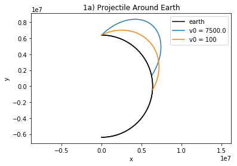

```python
# Gravity, constant acceleration
g     = 9.8

# Default options:
alpha = 0.0
beta  = 0.0
theta = 45.0				# (degrees)
R     = 6400000
GM    = g * R**2

dt = 0.1

thrust_list = [False, True]
v_list = [7.5*1000, 100]

for i, parameter in enumerate(thrust_list):

# Set parameters governing the numerical details
    thrust = parameter

    # Set initial position and velocity
    x0 = 0.0
    y0 = R
    v0 = v_list[i]				# unit: m/s

    # Determine components of the initial velocity vector
    vx0 = v0 * cos(theta * pi/180.0)
    vy0 = v0 * sin(theta * pi/180.0)

    # Initialize the trajectory
    t = 0
    x = x0
    y = y0
    r = sqrt(x**2 + y**2)
    vx = vx0
    vy = vy0

    #print x, y, t
    rmax = 0.0
    x_list = []
    y_list = []
    t_list = []

    while r >= R:

        x_list.append(x)
        y_list.append(y)
        t_list.append(t)

        rprev = sqrt(x**2 + y**2)
        tprev = t
        xprev = x
        yprev = y

        (x,y,vx,vy,t) = take_a_step(x, y, vx, vy, t, dt)

        r = sqrt(x**2 + y**2)

        if r > rmax: rmax = r

    rmax -= R
    tof   = interp(rprev, tprev, r, t,  x = R)

    x_range = interp(rprev, xprev, r, x,  x = R)
    y_range = interp(rprev, yprev, r, y,  x = R)

    the_range = atan(x_range/y_range) * R
    if the_range < 0:
        the_range = (-1*atan(y_range/x_range) + (pi/2)) * R

    plt.plot(xcircle, ycircle, 'k-', label = 'earth')
    plt.plot(x_list, y_list, '-', label = 'v0 = {}'.format(v0))
    plt.xlabel('x')
    plt.ylabel('y')
    plt.title('1a) Projectile Around Earth')
    plt.axis('equal')
    plt.legend()

    print('\nFor v0 = {}'.format(v0))
    print('Time of flight: {:.3f} s\nRange of flight: {:.3f} km\nMaximum: {:.3f} km'.format(tof, the_range/1000, rmax/1000 ))
```

1b)

```python
from math import *
def acc(x, y, vx, vy, t):
    global alpha, g, GM, thrust_time, reached_goal

    r_temp = sqrt(x**2 + y**2)
    v_abs  = sqrt(vx**2 + vy**2)

    beta = 1.6e-6 * exp((-r_temp + R) / 7000)

    ax_grav = -GM * x / r_temp**3
    ay_grav = -GM * y / r_temp**3

    ax_frict = -beta * v_abs * vx
    ay_frict = -beta * v_abs * vy

    ax_thrust = 10 * g * vx / v_abs
    ay_thrust = 10 * g * vy / v_abs

    if t <= thrust_time:
        return ax_grav + ax_thrust + ax_frict, ay_grav + ay_thrust + ay_frict
    else:
        return ax_grav + ax_frict, ay_grav + ay_frict

def take_a_step(x, y, vx, vy, t, dt):
    global thrust_time

    ax,ay = acc(x, y, vx, vy, t)

    # Predict:
    x  += vx*dt + 0.5*ax*dt*dt
    y  += vy*dt + 0.5*ay*dt*dt
    vx += ax*dt
    vy += ay*dt

    # Correct:
    ax1,ay1 = acc(x, y, vx, vy, t)

    vx += 0.5*(ax1-ax)*dt
    vy += 0.5*(ay1-ay)*dt

    t += dt

    return x,y,vx,vy,t
```

```python
# Gravity, constant acceleration
g     = 9.8

# Default options:
alpha = 0.0
beta  = 0.0
theta = 45.0				# (degrees)
v0    = 100				# unit: m/s
R     = 6400000
GM    = g * R**2

dt = 0.1
thrust_time = 75
reached_goal = False

while not reached_goal:

    # Set initial position and velocity
    x0 = 0.0
    y0 = R

    # Determine components of the initial velocity vector
    vx0 = v0 * cos(theta * pi/180.0)
    vy0 = v0 * sin(theta * pi/180.0)

    # Initialize the trajectory
    t = 0
    x = x0
    y = y0
    r = sqrt(x**2 + y**2)
    vx = vx0
    vy = vy0

    #print x, y, t
    rmax = 0.0
    x_list = []
    y_list = []
    t_list = []

    shutoff = False

    while (t < thrust_time + 3*dt) and (r >= R):
        x_list.append(x)
        y_list.append(y)
        t_list.append(t)

        rprev = sqrt(x**2 + y**2)
        tprev = t
        xprev = x
        yprev = y

        (x,y,vx,vy,t) = take_a_step(x, y, vx, vy, t, dt)

        r = sqrt(x**2 + y**2)
        r_temp = sqrt(x**2 + y**2)
        v_abs  = sqrt(vx**2 + vy**2)

        if t > thrust_time and not shutoff:
            escape_velocity = sqrt(2 * GM /r)
            shutoff = True
            if ((r - R) >= (100 * 1000)) and (v_abs >= escape_velocity):
                reached_goal = True
                velocity_at_escape = v_abs

    if not reached_goal:
        thrust_time += .1

print('Final Thrust time at t = {:.4f} s'.format(thrust_time))
print('Rocket reaches a velocity = {:.4f} km/s where the escape velocity is = {:.4f} km/s'.format(velocity_at_escape/1000, escape_velocity/1000 ))
```

```
Final Thrust time at t = 116.5000 s
Rocket reaches a velocity = 10.9621 km/s where the escape velocity is = 10.9552 km/s
```

2)

After that, another part of the program was done by varying the dt of three different orbits to show the effects that a too large of dt can have. After that, a variable dt was made that would decrease as it got closer to the center. This showed significantly more increased accuracy.

```python
def acc(x, y):
    # inverse-square law
    r = sqrt(x*x+y*y)
    return -GM*x/pow(r, 3), -GM*y/pow(r, 3)


def take_a_step(x, y, vx, vy, t, dt):
    # Predictor:
    ax, ay = acc(x, y)

    x  += vx*dt + 0.5*ax*dt*dt
    y  += vy*dt + 0.5*ay*dt*dt
    vx += ax*dt
    vy += ay*dt
    t  += dt

    # Corrector:
    ax1, ay1 = acc(x, y)

    vx += 0.5*(ax1-ax)*dt
    vy += 0.5*(ay1-ay)*dt

    return x,y,vx,vy,t
```

```
For r0 = 1.00, v0 = 1.00, the rmin = 1.00 and rmax = 1.00, and a = 1.00
For r0 = 1.00, v0 = 1.00, the Period = 6.28 and the ratio P^2 / a^3 = 39.50
And Eccentricity = 0.00

For r0 = 1.00, v0 = 0.90, the rmin = 0.68 and rmax = 1.00, and a = 0.84
For r0 = 1.00, v0 = 0.90, the Period = 4.84 and the ratio P^2 / a^3 = 39.56
And Eccentricity = 0.19

For r0 = 1.00, v0 = 0.70, the rmin = 0.32 and rmax = 1.00, and a = 0.66
For r0 = 1.00, v0 = 0.70, the Period = 3.39 and the ratio P^2 / a^3 = 39.56
And Eccentricity = 0.51

For r0 = 1.00, v0 = 1.10, the rmin = 1.00 and rmax = 1.53, and a = 1.27
For r0 = 1.00, v0 = 1.10, the Period = 8.95 and the ratio P^2 / a^3 = 39.49
And Eccentricity = 0.21

For r0 = 1.00, v0 = 1.30, the rmin = 1.00 and rmax = 5.45, and a = 3.23
For r0 = 1.00, v0 = 1.30, the Period = 36.41 and the ratio P^2 / a^3 = 39.48
And Eccentricity = 0.69

For r0 = 2.00, v0 = 0.60, the rmin = 1.13 and rmax = 2.00, and a = 1.56
For r0 = 2.00, v0 = 0.60, the Period = 12.28 and the ratio P^2 / a^3 = 39.50
And Eccentricity = 0.28

For r0 = 2.00, v0 = 0.90, the rmin = 2.00 and rmax = 8.53, and a = 5.26
For r0 = 2.00, v0 = 0.90, the Period = 75.87 and the ratio P^2 / a^3 = 39.48
And Eccentricity = 0.62
```

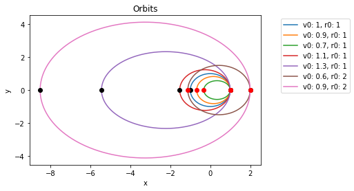

```python
GM = 1.0				# define units
r0_list = [1, 1, 1, 1, 1, 2, 2]
v0_list = [1,.9,.7,1.1,1.3,.6,.9]

for i in range(len(r0_list)):
    r0 = r0_list[i]
    v0 = v0_list[i]

    # Initialize the trajectory.
    t  = 0.0
    x  = r0
    y  = 0.0

    vx = 0.0
    vy = v0				# default is circular orbit

    dt    = 0.005
    t_max = 50.0

    xplot = [x]
    yplot = [y]

    rmax = r0
    rmin = r0

    xmax = x
    ymax = y

    xmin = x
    ymin = y


    while True:
        vx_p = vx

        (x,y,vx,vy,t) = take_a_step(x, y, vx, vy, t, dt)

        r_temp = sqrt(x**2 + y**2)

        if r_temp >= rmax:
            rmax = r_temp
            xmax = x
            ymax = y

        if r_temp <= rmin:
            rmin = r_temp
            xmin = x
            ymin = y

        xplot.append(x)
        yplot.append(y)

        if (vx_p > 0) and (vx <= 0):
            break

    plt.plot(xplot,yplot, label = 'v0: {}, r0: {}'.format(v0, r0))
    plt.plot(xmax, ymax, 'ko')
    plt.plot(xmin, ymin, 'ro')
    plt.title('Orbits')
    plt.xlabel('x')
    plt.ylabel('y')
    plt.legend()
    plt.legend(bbox_to_anchor=(1.4,1))

    a = .5*(rmin + rmax)
    ratio = t**2 / a ** 3
    eccentricity = 1 - rmin/a

    print('\nFor r0 = {:.2f}, v0 = {:.2f}, the rmin = {:.2f} and rmax = {:.2f}, and a = {:.2f}'.format(r0, v0, rmin, rmax, a))
    print('For r0 = {:.2f}, v0 = {:.2f}, the Period = {:.2f} and the ratio P^2 / a^3 = {:.2f}'.format(r0, v0, t, ratio))
    print('And Eccentricity = {:.2f}'.format(eccentricity))
```

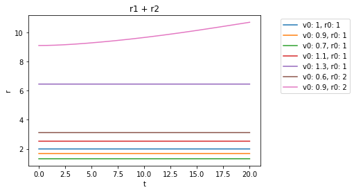

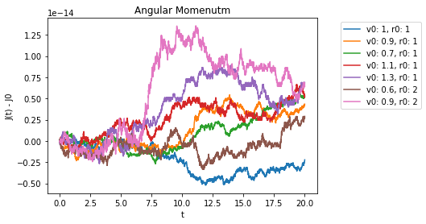

```python
GM = 1.0				# define units
r0_list = [1, 1, 1, 1, 1, 2, 2]
v0_list = [1,.9,.7,1.1,1.3,.6,.9]


for i in range(len(r0_list)):
    r0 = r0_list[i]
    v0 = v0_list[i]

    # Initialize the trajectory.
    t  = 0.0
    x  = r0
    y  = 0.0

    vx = 0.0
    vy = v0				# default is circular orbit
    J0 = (x * vy) - (y * vx)

    dt    = 0.005
    tmax = 20

    t_list =  [t]
    xplot = [x]
    yplot = [y]

    r_foci_list = []
    J_list = [J0 - J0]

    rmax = r0
    rmin = r0

    xmax = x
    ymax = y

    xmin = x
    ymin = y

    while t < tmax:
        vx_p = vx

        (x,y,vx,vy,t) = take_a_step(x, y, vx, vy, t, dt)

        r_temp = sqrt(x**2 + y**2)

        if r_temp >= rmax:
            rmax = r_temp
            xmax = x
            ymax = y

        if r_temp <= rmin:
            rmin = r_temp
            xmin = x
            ymin = y

        t_list.append(t)
        xplot.append(x)
        yplot.append(y)

        J_temp = (x * vy) - (y * vx)
        J_list.append(J_temp - J0)

        if (vx_p > 0) and (vx <= 0):
            pass


    a = .5*(rmin + rmax)
    ratio = t**2 / a ** 3
    eccentricity = 1 - (rmin/a)

    f1 = (0, 0)
    v_circular = 1 / sqrt(r0)

    if v0 < v_circular:
        f2 = (2*a*eccentricity, 0)
    elif v0 > v_circular:
        f2 = (-2*a*eccentricity, 0)
    else:
        f2 = (0, 0)

    for i in range(len(xplot)):
        r1x = xplot[i] - f1[0]
        r1y = yplot[i] - f1[1]
        r1 = sqrt(r1x**2 + r1y**2)

        r2x = xplot[i] - f2[0]
        r2y = yplot[i] - f2[1]
        r2 = sqrt(r2x**2 + r2y**2)

        r_foci_list.append(r1 + r2)

    plt.figure(1)
    plt.plot(t_list, r_foci_list, label = 'v0: {}, r0: {}'.format(v0, r0))
    plt.title('r1 + r2')
    plt.xlabel('t')
    plt.ylabel('r')
    plt.legend()
    plt.legend(bbox_to_anchor=(1.4,1))

    plt.figure(2)
    plt.plot(t_list, J_list, label = 'v0: {}, r0: {}'.format(v0, r0))
    plt.title('Angular Momenutm')
    plt.xlabel('t')
    plt.ylabel('J(t) - J0')
    plt.legend()
    plt.legend(bbox_to_anchor=(1.4,1))
```

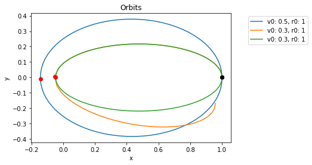

```python
GM = 1.0				# define units
r0_list = [1, 1, 1]
v0_list = [.5, .3, .3]
dt_list = [.01, .01, .001]

for i in range(len(r0_list)):
    r0 = r0_list[i]
    v0 = v0_list[i]

    # Initialize the trajectory.
    t  = 0.0
    x  = r0
    y  = 0.0

    vx = 0.0
    vy = v0				# default is circular orbit

    dt    = dt_list[i]
    t_max = 100

    xplot = [x]
    yplot = [y]

    rmax = r0
    rmin = r0

    xmax = x
    ymax = y

    xmin = x
    ymin = y


    while t <= tmax:
        vx_p = vx

        (x,y,vx,vy,t) = take_a_step(x, y, vx, vy, t, dt)

        r_temp = sqrt(x**2 + y**2)

        if r_temp >= rmax:
            rmax = r_temp
            xmax = x
            ymax = y

        if r_temp <= rmin:
            rmin = r_temp
            xmin = x
            ymin = y

        xplot.append(x)
        yplot.append(y)

        if (vx_p > 0) and (vx <= 0):
            break

    plt.plot(xplot,yplot, label = 'v0: {}, r0: {}'.format(v0, r0))
    plt.plot(xmax, ymax, 'ko')
    plt.plot(xmin, ymin, 'ro')
    plt.title('Orbits')
    plt.xlabel('x')
    plt.ylabel('y')
    plt.legend()
    plt.legend(bbox_to_anchor=(1.4,1))

    a = .5*(rmin + rmax)
    ratio = t**2 / a ** 3
    eccentricity = 1 - rmin/a
```

2f)

The Orbit for v0 = .3 and r0 = 1 differ detween dt = .01 and dt = .001. The orbit for the larger dt doesn't fully loop back onto itself.

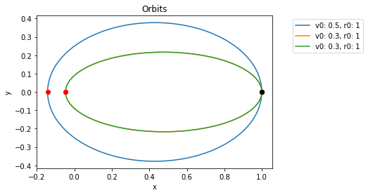

```python
GM = 1.0				# define units
r0_list = [1, 1, 1]
v0_list = [.5, .3, .3]
dt_list = [.01, .01, .001]

for i in range(len(r0_list)):
    r0 = r0_list[i]
    v0 = v0_list[i]

    # Initialize the trajectory.
    t  = 0.0
    x  = r0
    y  = 0.0

    vx = 0.0
    vy = v0				# default is circular orbit

    t_max = 100
    dt = .01 * pow(r0, 3/2)

    xplot = [x]
    yplot = [y]

    rmax = r0
    rmin = r0

    xmax = x
    ymax = y

    xmin = x
    ymin = y


    while t <= tmax:
        vx_p = vx

        (x,y,vx,vy,t) = take_a_step(x, y, vx, vy, t, dt)

        r_temp = sqrt(x**2 + y**2)
        dt = .01 * pow(r_temp, 3/2)

        if r_temp >= rmax:
            rmax = r_temp
            xmax = x
            ymax = y

        if r_temp <= rmin:
            rmin = r_temp
            xmin = x
            ymin = y

        xplot.append(x)
        yplot.append(y)

        if (vx_p > 0) and (vx <= 0):
            break

    plt.plot(xplot,yplot, label = 'v0: {}, r0: {}'.format(v0, r0))
    plt.plot(xmax, ymax, 'ko')
    plt.plot(xmin, ymin, 'ro')
    plt.title('Orbits')
    plt.xlabel('x')
    plt.ylabel('y')
    plt.legend()
    plt.legend(bbox_to_anchor=(1.4,1))

    a = .5*(rmin + rmax)
    ratio = t**2 / a ** 3
    eccentricity = 1 - rmin/a
```

This time, the orbital precession is zero the two orbits with the same r0 and v0 travel in the same orbit and don't leave that orbit and the axis of the orbit doesn't change.

Question 3

Comment: Modeled the figure eight motion of a rocket that circled around the moon and came back to the earth.

```python
def take_a_step(x, y, vx, vy, t, dt):

        ax,ay = acc(x, y, vx, vy, t)

        # Predict:
        x  += vx*dt + 0.5*ax*dt*dt
        y  += vy*dt + 0.5*ay*dt*dt
        vx += ax*dt
        vy += ay*dt

        # Correct:
        ax1,ay1 = acc(x, y, vx, vy, t)

        vx += 0.5*(ax1-ax)*dt
        vy += 0.5*(ay1-ay)*dt

        t += dt

        return x,y,vx,vy,t

def acc(x, y, vx, vy, t):


    x_earth = x - 0
    y_earth = y - 0

    x_moon = x - Moon_distance[0]
    y_moon = y - Moon_distance[1]

    r_earth = sqrt(x_earth**2 + y_earth**2)
    r_moon  = sqrt(x_moon**2 + y_moon**2)

    ax_earth = -GM * x_earth / r_earth**3
    ay_earth = -GM * y_earth / r_earth**3

    ax_moon = -G*Moon_M * x_moon / r_moon**3
    ay_moon = -G*Moon_M * y_moon / r_moon**3

    return ax_earth + ax_moon, ay_earth + ay_moon
```

```
For v0 = 11100.00 at an  launch angle = 42.00, the angle of collision from horizontal = -34.74 degrees
```

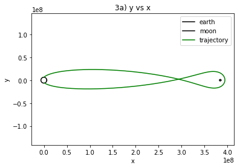

```python
import sys
from math import *
import matplotlib.pyplot as plt

# Gravity, constant acceleration
g     = 9.8
G = 6.67408e-11

# Default options:
alpha = 0.0
beta  = 0.0
theta = 42# (degrees)
v0    = 11.1*1000				# unit: m/s
Earth_R = 6400000
GM = g * Earth_R**2
Moon_R = .27 * Earth_R
Moon_M = .012 * GM / G
Moon_distance = (384000 * 1000, 0)


# Set parameters governing the numerical details
dt = .1

# Set initial position and velocity
x0 = 0.0
y0 = Earth_R

# Determine components of the initial velocity vector
vx0 = v0 * cos(theta * pi/180.0)
vy0 = v0 * sin(theta * pi/180.0)

# Initialize the trajectory
t = 0
x = x0
y = y0
r = sqrt(x**2 + y**2)

vx = vx0
vy = vy0

#print x, y, t
rmax = 0.0
x_list = []
y_list = []
t_list = []

while r >= R:

    x_list.append(x)
    y_list.append(y)
    t_list.append(t)

    rprev = sqrt(x**2 + y**2)
    tprev = t
    xprev = x
    yprev = y
    vxprev = vx
    vyprev = vy

    (x,y,vx,vy,t) = take_a_step(x, y, vx, vy, t, dt)

    r = sqrt(x**2 + y**2)

    if sqrt((Moon_distance[0] - x)**2 + (Moon_distance[1] - y)**2) < Moon_R:
        print('Rocket Crashed into Moon')
        break


xcircle_earth = []
ycircle_earth = []

xcircle_moon = []
ycircle_moon = []

temp_theta = 0
dtheta = pi/200

while temp_theta < 2*pi:

    xcircle_earth.append(Earth_R * cos(temp_theta))
    ycircle_earth.append(Earth_R * sin(temp_theta))

    xcircle_moon.append(Moon_R * cos(temp_theta) + Moon_distance[0])
    ycircle_moon.append(Moon_R * sin(temp_theta) + Moon_distance[1])

    temp_theta += dtheta



plt.plot(xcircle_earth, ycircle_earth, 'k-', label = 'earth')
plt.plot(xcircle_moon, ycircle_moon, 'k-', label = 'moon')
plt.plot(x_list, y_list, 'g-', label = 'trajectory')
plt.title('3a) y vs x')
plt.xlabel('x')
plt.ylabel('y')
plt.axis('equal')
plt.legend()

angle_of_collision = atan(vy/vx)
angle_of_collision = angle_of_collision * 180/pi
print('For v0 = {:.2f} at an  launch angle = {:.2f}, the angle of collision from horizontal = {:.2f} degrees'.format(v0, theta, angle_of_collision))
```

```python
def acc(x, y, vx, vy, t):


    x_earth = x - 0
    y_earth = y - 0

    x_moon = x - Moon_distance[0]
    y_moon = y - Moon_distance[1]

    r_earth = sqrt(x_earth**2 + y_earth**2)
    r_moon  = sqrt(x_moon**2 + y_moon**2)

    ax_earth = -GM * x_earth / r_earth**3
    ay_earth = -GM * y_earth / r_earth**3

    ax_moon = -G*Moon_M * x_moon / r_moon**3
    ay_moon = -G*Moon_M * y_moon / r_moon**3

    ax_sun = 0
    ay_sun = 2 * A * y

    return ax_earth + ax_moon + ax_sun, ay_earth + ay_moon + ay_sun
```

```
For v0 = 11100.00 at an  launch angle = 42.00, the rocket does not reach earth and misses by 1154554.0348636713 m
The x-component of the acceleration of the field is 0
The y-component of the acceleration of the field is 2*A*y
```

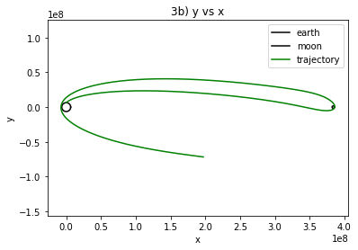

```python
A = 1.2e-11

# Gravity, constant acceleration
g     = 9.8
G = 6.67408e-11

# Default options:
alpha = 0.0
beta  = 0.0
theta = 42# (degrees)
v0    = 11.1*1000				# unit: m/s
Earth_R = 6400000
GM = g * Earth_R**2
Moon_R = .27 * Earth_R
Moon_M = .012 * GM / G
Moon_distance = (384000 * 1000, 0)


# Set parameters governing the numerical details
dt = .1

# Set initial position and velocity
x0 = 0.0
y0 = Earth_R

# Determine components of the initial velocity vector
vx0 = v0 * cos(theta * pi/180.0)
vy0 = v0 * sin(theta * pi/180.0)

# Initialize the trajectory
t = 0
x = x0
y = y0
r = sqrt(x**2 + y**2)

vx = vx0
vy = vy0

#print x, y, t
rmin = Moon_distance[0]
x_list = []
y_list = []
t_list = []

while t < 750000:

    x_list.append(x)
    y_list.append(y)
    t_list.append(t)

    rprev = sqrt(x**2 + y**2)
    tprev = t
    xprev = x
    yprev = y
    vxprev = vx
    vyprev = vy

    (x,y,vx,vy,t) = take_a_step(x, y, vx, vy, t, dt)

    r = sqrt(x**2 + y**2)

    if t > 1000:
        if r <= rmin: rmin = r

    if sqrt((Moon_distance[0] - x)**2 + (Moon_distance[1] - y)**2) < Moon_R:
        print('Rocket Crashed into Moon')
        break


xcircle_earth = []
ycircle_earth = []

xcircle_moon = []
ycircle_moon = []

temp_theta = 0
dtheta = pi/200

while temp_theta < 2*pi:

    xcircle_earth.append(Earth_R * cos(temp_theta))
    ycircle_earth.append(Earth_R * sin(temp_theta))

    xcircle_moon.append(Moon_R * cos(temp_theta) + Moon_distance[0])
    ycircle_moon.append(Moon_R * sin(temp_theta) + Moon_distance[1])

    temp_theta += dtheta


plt.plot(xcircle_earth, ycircle_earth, 'k-', label = 'earth')
plt.plot(xcircle_moon, ycircle_moon, 'k-', label = 'moon')
plt.plot(x_list, y_list, 'g-', label = 'trajectory')
plt.title('3b) y vs x')
plt.xlabel('x')
plt.ylabel('y')
plt.axis('equal')
plt.legend()

angle_of_collision = atan(vy/vx)
angle_of_collision = angle_of_collision * 180/pi
print('For v0 = {:.2f} at an  launch angle = {:.2f}, the rocket does not reach earth and misses by {} m'.format(v0, theta, rmin-R))
print('The x-component of the acceleration of the field is 0')
print('The y-component of the acceleration of the field is 2*A*y')
```